# Livre de Bivand

jcb

16 octobre 2016

# Chapitre 2

La classse de base est **Spatial** qui comporte 2 slots:

- bounding box: matrice 2x2. La première ligne correspond aux limites *est* (axe des X) et la seconde aux limites *nord* (axe des Y).
- un objet **CRS** qui définit le système de coordonnées. Sa valeur par défaut est NA (Pas disponible).

```r
library(sp)
file <- "/Users/jcb/Documents/Cartographie/Applied_Spatial_Data_Analysis/Data/CRAN051001a.txt"
CRAN_df <- read.table(file, header = TRUE)
CRAN_mat <- cbind(CRAN_df$long, CRAN_df$lat)
row.names(CRAN_mat) <- 1:nrow(CRAN_mat)
head(CRAN_df)
```

```
##            place   north     east       loc      long       lat
## 1       Brisbane 27d28'S 153d02'E Australia 153.03333 -27.46667
## 2      Melbourne 37d49'S 144d58'E Australia 144.96667 -37.81667
## 3           Wien 48d13'N  16d20'E   Austria  16.33333  48.21667
## 4       Curitiba 25d25'S  49d16'W    Brazil -49.26667 -25.41667
## 5      Vi\xe7oza 20d45'S  42d52'W    Brazil -42.86667 -20.75000
## 6 Rio de Janeiro 22d54'S  43d12'W    Brazil -43.20000 -22.90000
```

```r
str(CRAN_mat)
```

```
##  num [1:54, 1:2] 153 145 16.3 -49.3 -42.9 ...
##  - attr(*, "dimnames")=List of 2
##   ..$ : chr [1:54] "1" "2" "3" "4" ...
##   ..$ : NULL
```

```r
# On ajoute un objet CRS
llCRS <- CRS("+proj=longlat +ellps=WGS84")
CRAN_sp <- SpatialPoints(CRAN_mat, proj4string = llCRS)
summary(CRAN_sp)
```

```
## Object of class SpatialPoints
## Coordinates:
##                  min      max
## coords.x1 -122.95000 153.0333
## coords.x2  -37.81667  57.0500
## Is projected: FALSE
## proj4string : [+proj=longlat +ellps=WGS84]
## Number of points: 54
```

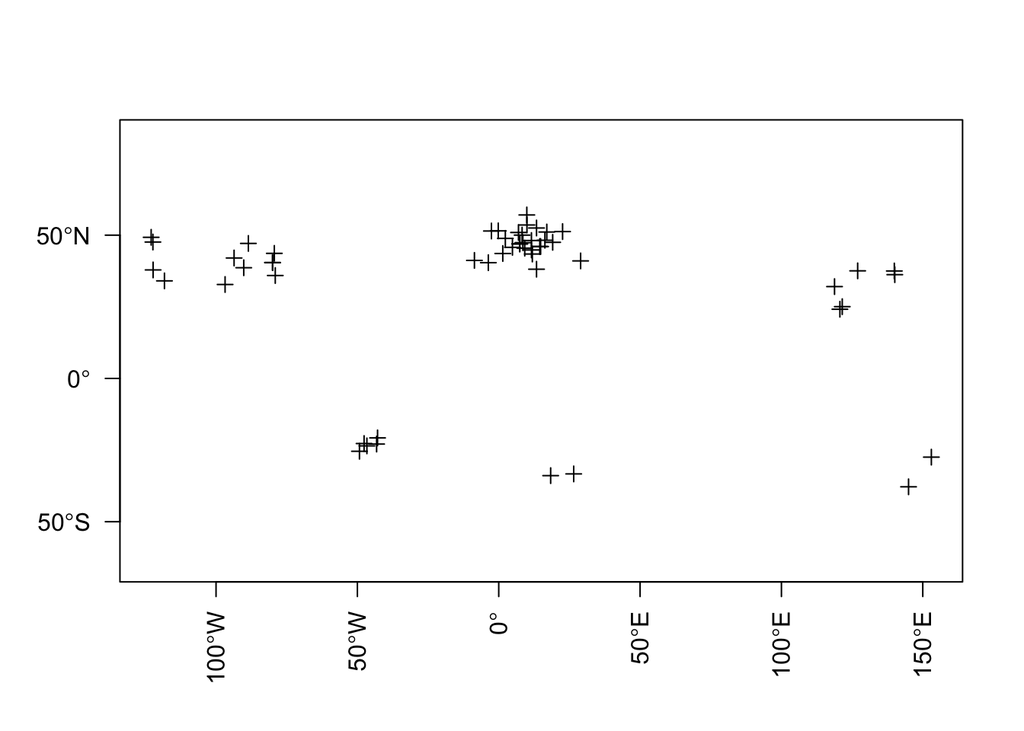

```r
plot(CRAN_sp, axes = T, las = 2)
```

# Chapitre 4 - Coordinates Reference System (CRS)

CRS est le coeur des systèmes cartographiques. Il est toujours associé à une **ellipse** représentant le patatoïde terrestre, un **méridien origine** (Greenwich) et des **données** (Datum). Les données sont arbitraires et accrochent le CRS à un point en 3 dimensions. L’ellipsoÏde le plus utilisé est **WGS84**. Il existe plusieurs milliers de CRS. Ils sont rassemblés par l’EPSG qui les publie via la bibliothèque **PROJ.4**. Une copie est disponible par la librairie **rgdal**. rgdal permet de lire EPSG dans un dataframe et de faire des recherches va **grep**.

```r
library(rgdal)
EPSG <- make_EPSG()
head(EPSG)
```

```
##   code                                               note
## 1 3819                                           # HD1909
## 2 3821                                            # TWD67
## 3 3824                                            # TWD97
## 4 3889                                             # IGRS
## 5 3906                                         # MGI 1901
## 6 4001 # Unknown datum based upon the Airy 1830 ellipsoid
##                                                                                            prj4
## 1 +proj=longlat +ellps=bessel +towgs84=595.48,121.69,515.35,4.115,-2.9383,0.853,-3.408 +no_defs
## 2                                                         +proj=longlat +ellps=aust_SA +no_defs
## 3                                    +proj=longlat +ellps=GRS80 +towgs84=0,0,0,0,0,0,0 +no_defs
## 4                                    +proj=longlat +ellps=GRS80 +towgs84=0,0,0,0,0,0,0 +no_defs
## 5                            +proj=longlat +ellps=bessel +towgs84=682,-203,480,0,0,0,0 +no_defs
## 6                                                            +proj=longlat +ellps=airy +no_defs
```

On chercherche ED50

```r
EPSG[grep("^# ED50$", EPSG$note),]
```

```
##     code   note
## 159 4230 # ED50
##                                                                 prj4
## 159 +proj=longlat +ellps=intl +towgs84=-87,-98,-121,0,0,0,0 +no_defs
```

## Structure d’un CRS

Le CRS traduit les spécifications de la librairie PROJ.4 sous la forme d’un couple *tag=value* entourés de *guillemets*. Attention, les espaces ont un sens => ne pas les utiliser. Un tag commence toujours par le signe **+**, suivi du nom du tag, puis le signe **=**. Le symbole *espace* sert à séparer plusieurs tags.

``+init=EPSG:4230`

```r
ED50 <- CRS("+init=EPSG:4230")
ED50
```

```
## CRS arguments:
##  +init=EPSG:4230 +proj=longlat +ellps=intl
## +towgs84=-87,-98,-121,0,0,0,0 +no_defs
```

CRS arguments: +init=EPSG:4230 +proj=longlat +ellps=intl +towgs84=-87,-98,-121,0,0,0,0 +no_defs

Il y a 4 tags:

- proj=longlat => utilise des coordnnées géographiques
- ellps = int1 correspoond à l’élipsoide de 1909 (Hayford)
- towgs84=-87,-98,-121,0,0,0,0 vecteur de translation spatiale X,Y,Z
- no_defs

Application: on relève un point sur une carte coordonnées ED50 et on veut le même point en WSG84.

```r
east <- as(char2dms("4d31'00\"E"), "numeric")
east
```

```
## [1] 4.516667
```

```r
nord <- as(char2dms("52d28'00\"N"), "numeric")
nord
```

```
## [1] 52.46667
```

```r
IJ.ED50 <- SpatialPoints(cbind(x = east, y = nord ), proj4string = ED50)
res <- spTransform(IJ.ED50, CRS("+proj=longlat +datum=WGS84"))
res@coords
```

```
##            x        y
## [1,] 4.51533 52.46588
```